# RT Network Analysis - Metric Exploration

- Show All Code
- Hide All Code
- View Source

Author

Harshini Karthikeyan, Alex Ralston, Jack Colt, Chelsey Harper

```r
library(tidyverse)
library(purrr)
library(lubridate)
library(kableExtra)
devtools::load_all("../")
```

## Variants of Betweenness

### Standard Betweenness Centrality

**What is betweenness centrality?**  
The sum of probabilities of passing through a given node on the shortest path between two others.

**What it describes in the network:**  
Betweenness highlights individuals who facilitate direct and indirect interactions between nodes. It captures a quality of bridging two nodes, but not necessarily bridging between two clusters or political factions, in our case.

**Why does this fall short when considering our research questions?**  
Betweenness needs to be modified to capture the moderating behavior between Government and Opposition. It’s also not a direct indication of local bridging behavior, really more of a global view. Standard betweenness doesn’t take weights into account; also assumes shortest paths are the relevant paths.

**Formula:**
$$C_B(v) = \sum_{s \neq v \neq t}\frac{\sigma_{st}(v)}{\sigma_{st}}$$

Where:  
- $\sigma_{st}$: Total number of shortest paths from node $s$ to node $t$.  
- $\sigma_{st}(v)$: Number of shortest paths from node $s$ to $t$ that pass through $v$.

### Candidate Variant #1 - Cross-Betweenness

**What are we altering?**  
Instead of considering the shortest path between every pair of nodes, we only use distinct pairs of nodes with opposing affiliation (Government and Opposition).

Here we only evaluate the ability of a node to bridge the gap between the factions.

We ignore connectivity within each faction, since this is not relevant to our research.

**Formula:**
$$C_B(v) = \sum_{o \neq v \neq g}\frac{\sigma_{og}(v)}{\sigma_{og}}$$

Where:  
- $\sigma_{og}$: Total number of shortest paths from node $o$, an opposition node, to node $g$, a government node.  
- $\sigma_{og}(v)$: Number of shortest paths from node $o$ to $g$ that pass through $v$.

**Concerns / Potential Pitfalls:**  
Large, dense clusters can skew the centrality, inflating the scores of nodes because they lie on multiple paths within the same cluster. This could mask who is genuinely “important” as a moderator.  
Perhaps indirect interactions are not as important as direct interactions, in which case the global nature of this method doesn’t help us in our research.

#### Exploring this Variant (Cross-Betweenness)

Below we’ll share a glimpse at the top 20 highest cross-betweenness results. The results are currently calculated for a single year. This is only because our function needs to be optimized (happening soon).

The highest cross-betweenness results are exhibited by **Walerian Pańko** in 1982 and **Kazimierz Obsadny** in 1987.

```r
# loading results of candidate variant #1 "Cross Betweenness"
cb_by_year <- read_csv("cb_initial_results.csv")

cb_by_year |> arrange(desc(CrossBetweenness)) |>
  slice_max(order_by = CrossBetweenness, n = 20) |>
  kable(format = "html", caption = "Highest 20 Cross-Betweenness Results") |>
  kable_styling(bootstrap_options = c("striped", "hover", "condensed"), full_width = F)
```

Highest 20 Cross-Betweenness Results

| Member.ID | CrossBetweenness | Start.Date | End.Date | Full.Name | RT.Affiliation |
| --- | --- | --- | --- | --- | --- |
| MEM0142 | 14161.798 | 1982-01-01 | 1982-12-31 | Walerian Pańko | Opposition |
| MEM0272 | 12024.596 | 1987-01-01 | 1987-12-31 | Kazimierz Obsadny | Government |
| MEM0229 | 5354.350 | 1985-01-01 | 1985-12-31 | Andrzej Ziabicki | Expert |
| MEM0247 | 4597.045 | 1989-01-01 | 1989-12-31 | Alfred Miodowicz | Government |
| MEM0229 | 4252.025 | 1983-01-01 | 1983-12-31 | Andrzej Ziabicki | Expert |
| MEM0229 | 4196.185 | 1984-01-01 | 1984-12-31 | Andrzej Ziabicki | Expert |
| MEM0230 | 4154.471 | 1989-01-01 | 1989-12-31 | Tadeusz Zieliński | Opposition |
| MEM0230 | 4036.975 | 1988-01-01 | 1988-12-31 | Tadeusz Zieliński | Opposition |
| MEM0247 | 4028.795 | 1988-01-01 | 1988-12-31 | Alfred Miodowicz | Government |
| MEM0247 | 3922.914 | 1986-01-01 | 1986-12-31 | Alfred Miodowicz | Government |
| MEM0247 | 3381.670 | 1984-01-01 | 1984-12-31 | Alfred Miodowicz | Government |
| MEM0247 | 3283.586 | 1985-01-01 | 1985-12-31 | Alfred Miodowicz | Government |
| MEM0252 | 3211.582 | 1986-01-01 | 1986-12-31 | Władysław Siła-Nowicki | Government |
| MEM0084 | 3137.443 | 1989-01-01 | 1989-12-31 | Stefan Jurczak | Opposition |
| MEM0252 | 3098.462 | 1987-01-01 | 1987-12-31 | Władysław Siła-Nowicki | Government |
| MEM0084 | 3068.911 | 1986-01-01 | 1986-12-31 | Stefan Jurczak | Opposition |
| MEM0115 | 3043.500 | 1979-01-01 | 1979-12-31 | Wojciech Lamentowicz | Opposition |
| MEM0272 | 2991.712 | 1986-01-01 | 1986-12-31 | Kazimierz Obsadny | Government |
| MEM0115 | 2888.576 | 1978-01-01 | 1978-12-31 | Wojciech Lamentowicz | Opposition |
| MEM0272 | 2785.655 | 1989-01-01 | 1989-12-31 | Kazimierz Obsadny | Government |

When we compare **Jacek Kuroń** and **Lech Wałęsa** as Dr. Bodwin suggested, we see their cross-betweenness plots exhibit the predicted inversion.

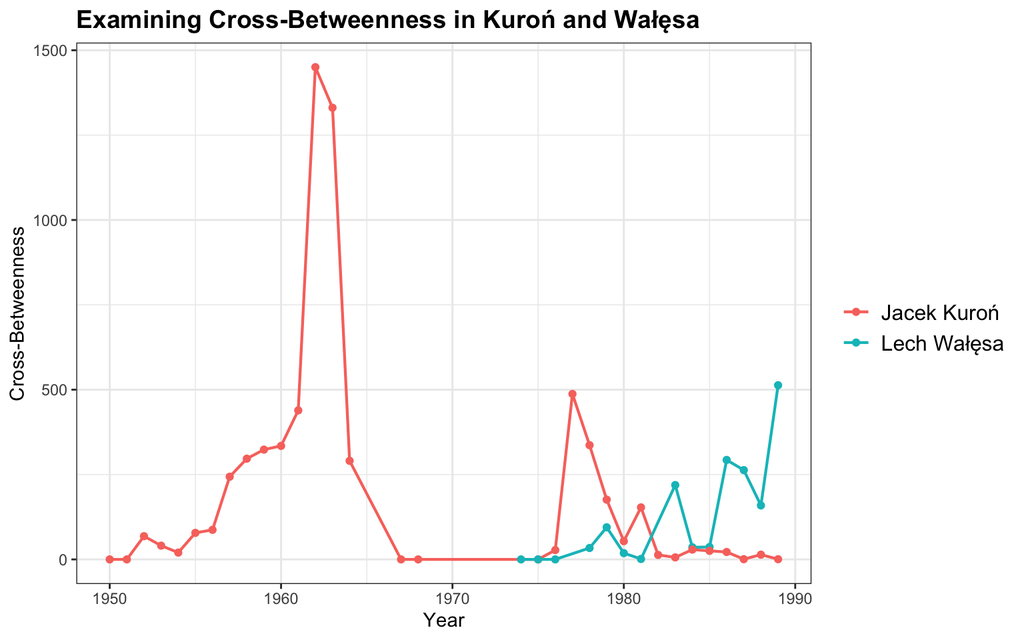

```r
# Comparing Walesa and Kuron as suggested by Bodwin

cb_kuron_walesa <- cb_by_year |>
  filter(Full.Name %in% c("Jacek Kuroń", "Lech Wałęsa")) |>
    ggplot(mapping = aes(x = Start.Date,
                       y = CrossBetweenness,
                       group = Member.ID,
                       color = Full.Name)) +
  geom_line(linewidth = .75) +
  geom_point() +
  labs(title = 'Examining Cross-Betweenness in Kuroń and Wałęsa',
       x = 'Year',
       y = 'Cross-Betweenness',
       color = '') +
  theme_bw() +
  theme(plot.title = element_text(face = "bold", size = 14),
        legend.text = element_text(size = 12))

cb_kuron_walesa
```

Now, we find the individuals with the highest cross-betweenness on average. Plotting their scores, we see consistently high cb from **Andrzej Ziabicki** and **Jan Waleczek**, but **Stefan Jurczak** and **Tadeusz Zieliński** really spike in the later years.

```r
# I would like to see what individuals have the highest cross-betweenness on average
# filter the data down to include only these
# then visualize

top_5 <- cb_by_year |>
  group_by(Member.ID) |>
  summarise(avg_cb = mean(CrossBetweenness),
            Full.Name = first(Full.Name),
            RT.Affiliation = first(RT.Affiliation)) |>
  arrange(desc(avg_cb)) |>
  slice_max(order_by = avg_cb, n = 5)

top_5 |>
  kable(format = "html", caption = "Highest 5 Average Cross-Betweenness Over Time") |>
  kable_styling(bootstrap_options = c("striped", "hover", "condensed"), full_width = F)
```

Highest 5 Average Cross-Betweenness Over Time

| Member.ID | avg_cb | Full.Name | RT.Affiliation |
| --- | --- | --- | --- |
| MEM0272 | 1422.9342 | Kazimierz Obsadny | Government |
| MEM0229 | 1155.6874 | Andrzej Ziabicki | Expert |
| MEM0230 | 1059.0505 | Tadeusz Zieliński | Opposition |
| MEM0084 | 1025.1236 | Stefan Jurczak | Opposition |
| MEM0462 | 923.2615 | Jan Waleczek | Government |

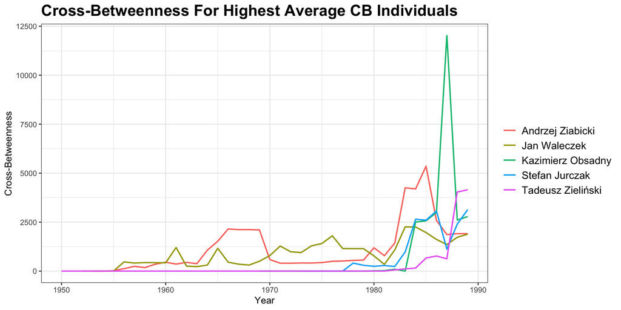

```r
cb_top_5_plot <- cb_by_year |>
  semi_join(top_5, by = 'Member.ID')

cb_top_5_plot |>
  ggplot(aes(x = Start.Date, y = CrossBetweenness, color = Full.Name)) +
  geom_line(linewidth = 0.75) +
  # geom_point() +
  theme_bw() +
  labs(title = "Cross-Betweenness For Highest Average CB Individuals",
       x = "Year",
       y = "Cross-Betweenness",
       color = "") +
   theme(plot.title = element_text(face = "bold", size = 18),
        legend.text = element_text(size = 12))
```

Here we look at 5 experts with highest average cross-betweenness scores.

```r
top_5_experts <- cb_by_year |>
  filter(RT.Affiliation == c("Expert")) |>
  group_by(Member.ID) |>
  summarise(avg_cb = mean(CrossBetweenness),
            Full.Name = first(Full.Name)) |>
  arrange(desc(avg_cb)) |>
  slice_max(order_by = avg_cb, n = 5)

cb_top_5_expert_plot <- cb_by_year |>
  semi_join(top_5_experts, by = 'Member.ID')

top_5_experts |>
  kable(format = "html", caption = "Highest Average Cross-Betweenness Experts Over Time") |>
  kable_styling(bootstrap_options = c("striped", "hover", "condensed"), full_width = F)
```

Highest Average Cross-Betweenness Experts Over Time

| Member.ID | avg_cb | Full.Name |
| --- | --- | --- |
| MEM0229 | 1155.6874 | Andrzej Ziabicki |
| MEM0139 | 820.8965 | Edward Olszewski |
| MEM0293 | 428.7067 | Adam Lipowski |
| MEM0211 | 190.4215 | Jerzy Wertenstein-Żuławski |
| MEM0572 | 177.3812 | Maciej Szumowski |

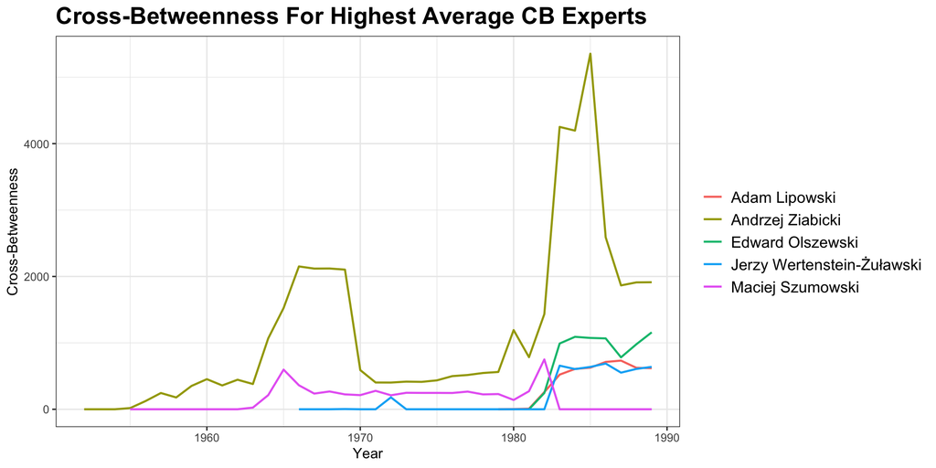

```r
cb_top_5_expert_plot |>
  ggplot(aes(x = Start.Date, y = CrossBetweenness, color = Full.Name)) +
  geom_line(linewidth = 0.75) +
  # geom_point() +
  theme_bw() +
  labs(title = "Cross-Betweenness For Highest Average CB Experts",
       x = "Year",
       y = "Cross-Betweenness",
       color = "") +
   theme(plot.title = element_text(face = "bold", size = 18),
        legend.text = element_text(size = 12))
```

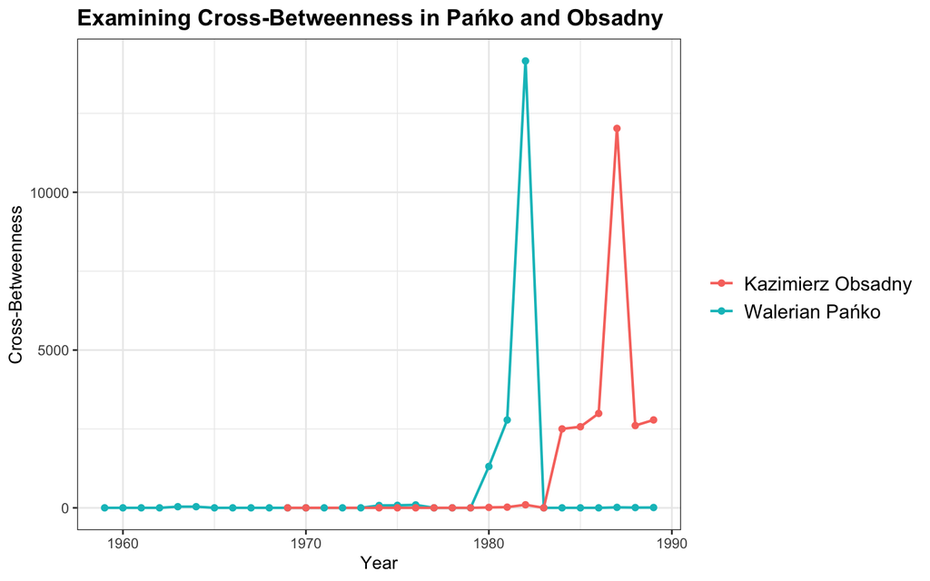

```r
# Comparing Pańko and Obsadny

cb_panko_obsadny <-
  cb_by_year |>
  filter(Full.Name %in% c("Walerian Pańko", "Kazimierz Obsadny")) |>
    ggplot(mapping = aes(x = Start.Date,
                       y = CrossBetweenness,
                       group = Member.ID,
                       color = Full.Name)) +
  geom_line(linewidth = .75) +
  geom_point() +
  labs(title = 'Examining Cross-Betweenness in Pańko and Obsadny',
       x = 'Year',
       y = 'Cross-Betweenness',
       color = '') +
  theme_bw() +
  theme(plot.title = element_text(face = "bold", size = 14),
        legend.text = element_text(size = 12))

cb_panko_obsadny
```

These high spikes definitely pique our interest. **Pańko’s** spike in 1982 corresponds with when he left PZPR. We took a look at the network app around this time and saw behavior in the graph that seems to validate our metric calculation.

##### Walerian Pańko – 1979

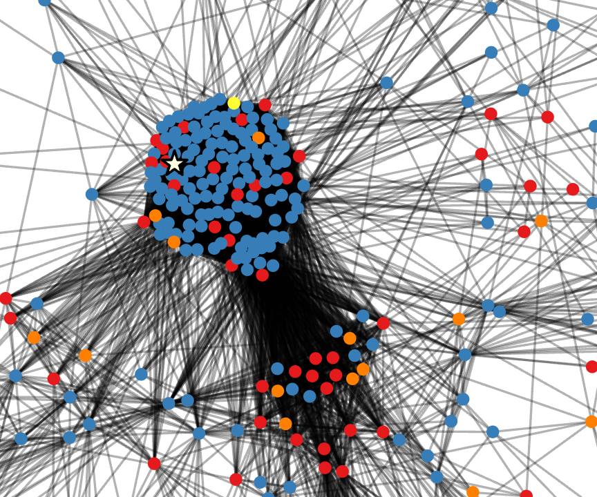

Pańko 1979

##### Walerian Pańko – 1980

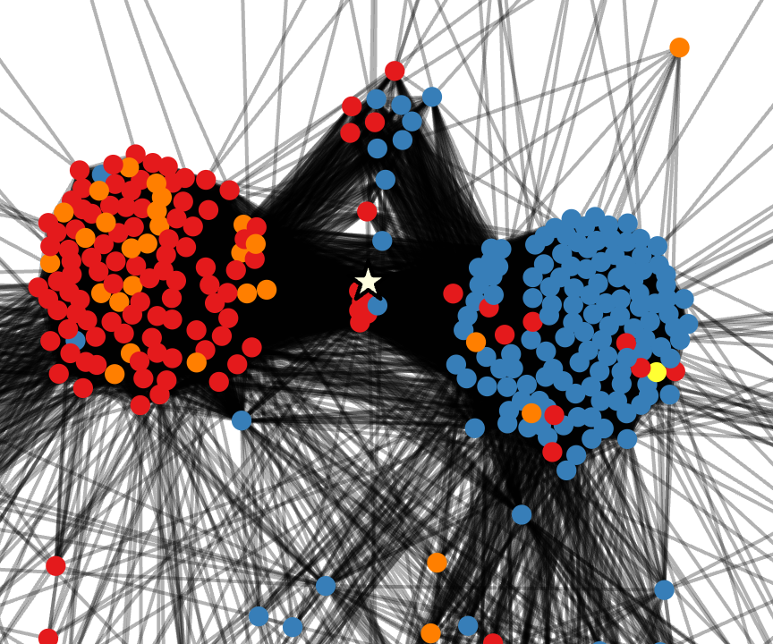

Pańko 1980

##### Walerian Pańko – 1981

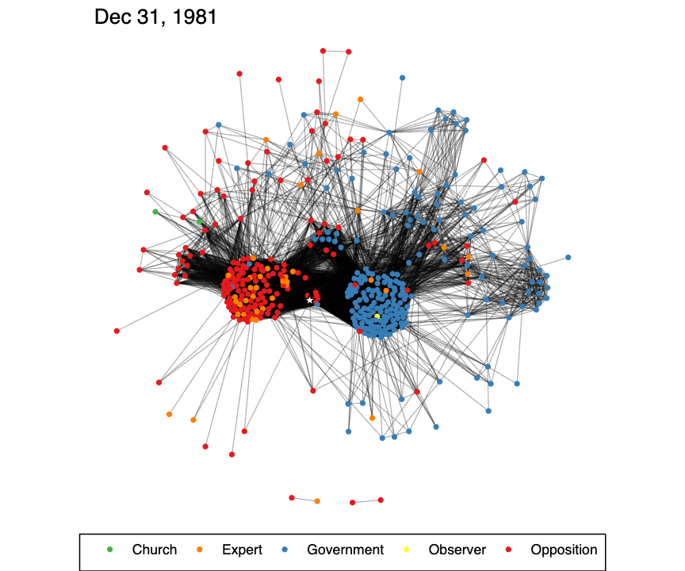

Pańko 1981

##### Walerian Pańko – 1983

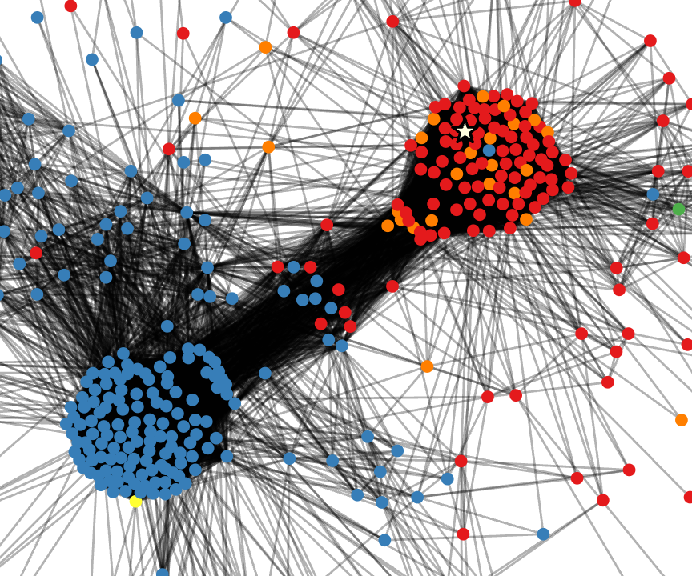

Pańko 1983

Dr. Domber also suggested taking a look at two individuals that may be good examples of potential moderation **Wladyslaw Sila-Nowick** and **Wojciech Lamentowicz**.

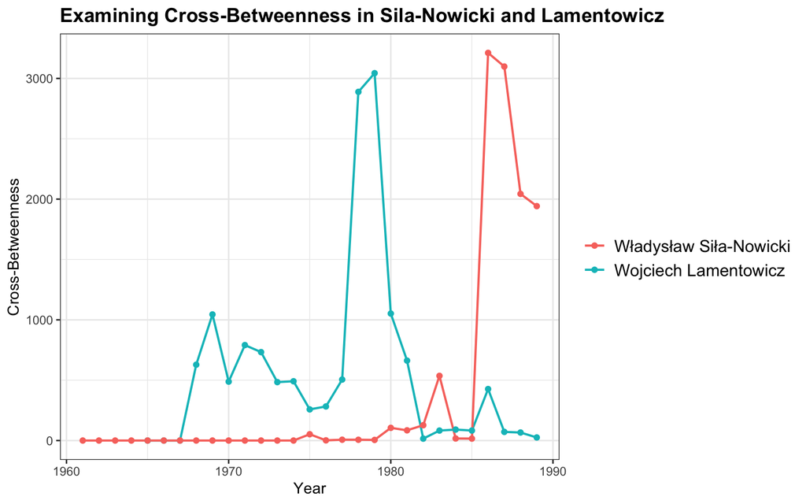

```r
# Comparing Wladyslaw Sila-Nowicki and Wojciech Lamentowicz

cb_by_year |>
  filter(Member.ID %in% c("MEM0252", "MEM0115")) |>
    ggplot(mapping = aes(x = Start.Date,
                       y = CrossBetweenness,
                       group = Member.ID,
                       color = Full.Name)) +
  geom_line(linewidth = .75) +
  geom_point() +
  labs(title = 'Examining Cross-Betweenness in Sila-Nowicki and Lamentowicz',
       x = 'Year',
       y = 'Cross-Betweenness',
       color = '') +
  theme_bw() +
  theme(plot.title = element_text(face = "bold", size = 14),
        legend.text = element_text(size = 12))
```

Now that Dr. Domber has given us the list of exchange participants, we thought it might be interesting to look at their cross-betweenness scores.

```r
exchange_participants <- read_csv('RT_Exchange_Participants.csv')
```

```r
exchange_list <- list(exchange_participants$Member.ID)
```

```r
# cb_by_year |>
#   filter(Member.ID %in% c("MEM0009", "MEM0031", "MEM0046","MEM0049","MEM0083")) |>
#   ggplot(mapping = aes(x = Start.Date,
#                        y = CrossBetweenness,
#                        group = Member.ID,
#                        color = Full.Name)) +
#   geom_line(linewidth = .75) +
#   geom_point() +
#   labs(title = 'Examining Cross-Betweenness in Exchange Participants',
#        x = 'Year',
#        y = 'Cross-Betweenness',
#        color = '') +
#   theme_bw()+
#   theme(plot.title = element_text(face = 'bold', size = 14),
#         legend.text = element_text(size = 12))

cb_by_year |>
  filter(Member.ID %in% exchange_list[[1]]) |>
  group_by(Member.ID) |>
  summarise(avg_cb = mean(CrossBetweenness),
            Full.Name = first(Full.Name)) |>
  arrange(desc(avg_cb)) |>
  kable(format='html', caption='Cross-Betweenness in Exchange Participants') |>
  kable_styling(bootstrap_options = c('striped', 'hover', 'condensed'), full_width = F)
```

Cross-Betweenness in Exchange Participants

| Member.ID | avg_cb | Full.Name |
| --- | --- | --- |
| MEM0485 | 528.0389170 | Jerzy Wiatr |
| MEM0066 | 495.9266636 | Janusz Grzelak |
| MEM0526 | 488.2380129 | Wojciech Sokolewicz |
| MEM0135 | 365.9772605 | Jan Mujżel |
| MEM0179 | 331.8076127 | Adam Stanowski |
| MEM0302 | 308.0938363 | Grzegorz Kołodko |
| MEM0482 | 284.4460568 | Janusz Reykowski |
| MEM0206 | 208.2022487 | Jerzy Turowicz |
| MEM0408 | 200.8838951 | Jerzy Niemiec |
| MEM0049 | 196.0947580 | Władysław Findeisen |
| MEM0004 | 196.0801061 | Stefan Amsterdamski |
| MEM0075 | 183.8732984 | Janina Jankowska |
| MEM0141 | 163.3955255 | Janusz Onyszkiewicz |
| MEM0317 | 156.7872854 | Marcin święcicki |
| MEM0305 | 153.6501427 | Wincenty Lewandowski |
| MEM0231 | 153.1017571 | Janusz Ziółkowski |
| MEM0215 | 149.8298986 | Zbigniew Wierzbicki |
| MEM0025 | 147.3343401 | Andrzej Celiński |
| MEM0416 | 135.9992095 | Marian Wojciechowski |
| MEM0205 | 128.4668581 | Witold Trzeciakowski |
| MEM0506 | 126.6357634 | Piotr Chojnacki |
| MEM0487 | 106.1263043 | Sylwester Zawadzki |
| MEM0220 | 94.3771565 | Jacek Woźniakowski |
| MEM0309 | 93.8985271 | Józef Okuniewski |
| MEM0009 | 92.9304627 | Ryszard Bender |
| MEM0053 | 67.5567733 | Bronisław Geremek |
| MEM0104 | 65.0000581 | Marcin Król |
| MEM0241 | 53.9078159 | Jan Kostrzewski |
| MEM0183 | 53.5354063 | Antoni Stawikowski |
| MEM0479 | 53.3834282 | Heironim Kubiak |
| MEM0046 | 49.9035927 | Lech Falandysz |
| MEM0187 | 46.0454139 | Stanisław Stomma |
| MEM0483 | 43.3178066 | Karol Szyndzielorz |
| MEM0525 | 43.2269250 | Kazimierz Secomski |
| MEM0134 | 38.6138511 | Jacek Moskwa |
| MEM0554 | 35.7919177 | Włodzimierz Łoziński |
| MEM0110 | 35.3331625 | Władysław J.H. Kunicki-Goldfinger |
| MEM0533 | 33.9093621 | Tomasz Langer |
| MEM0242 | 30.3648390 | Mikołaj Kozakiewicz |
| MEM0031 | 29.3865276 | Paweł Czartoryski |
| MEM0175 | 26.7342602 | Magdalena Sokołowska |
| MEM0019 | 24.4909335 | Stefan Bratkowski |
| MEM0468 | 21.9687181 | Andrzej Wojtczak |
| MEM0191 | 17.6666667 | Andrzej Szczeklik |
| MEM0073 | 15.9655630 | Maciej Tadeusz Iłowiecki |
| MEM0192 | 14.5297534 | Jan Józef Szczepański |
| MEM0397 | 14.2869117 | Jacek Fisiak |
| MEM0083 | 11.3881767 | Stanisław Juchnowicz |
| MEM0035 | 8.9685774 | Tadeusz Diem |
| MEM0449 | 7.0680144 | Stanisław śliwiński |
| MEM0101 | 5.6178471 | Krzysztof Kozłowski |
| MEM0258 | 3.9132977 | Bronisław Dembowski |
| MEM0549 | 0.8947368 | Zygmunt Kałużyński |
| MEM0528 | 0.0345807 | Jan Szreniawski |
| MEM0111 | 0.0000000 | Gotfryd Kupryszewski |
| MEM0279 | 0.0000000 | Maria Matey-Tyrowicz |
| MEM0358 | 0.0000000 | Andrzej Hrynkiewicz |
| MEM0538 | 0.0000000 | Barbara Zawadzka |

### Candidate Variant #2 - Cluster-Norm Cross-Betweenness

**What are we altering?**  
We still consider the shortest paths between pairs of nodes of opposing factions, but to combat the score inflation from large organizations, we introduce a normalizing factor.  
We divide by the product of cluster sizes of each of the target nodes.

**Formula:**
$$C_B(v) = \sum_{o \neq v \neq g}\frac{\sigma_{og}(v)}{\sigma_{og}} \cdot \frac{1}{|C_o| \cdot |C_g|}$$

Where:  
- $\sigma_{og}$: Total number of shortest paths from node $o$, an opposition node, to node $g$, a government node.  
- $\sigma_{og}(v)$: Number of shortest paths from node $o$ to $g$ that pass through $v$.  
- $|C_o|$: Size of the cluster containing node $o$.  
- $|C_g|$: Size of the cluster containing node $g$.

**Concerns / Potential Pitfalls:**  
We are still considering indirect interactions here, which may or may not be appropriate.  
While mitigating against large clusters skewing the results, we may be giving undue influence to smaller clusters. Perhaps adjusting the normalization by some factor could help.

#### Analysis of Results

```r
# loading results of candidate variant #2 "Cluster-Normalized Cross Betweenness"
norm_cross_betweenness_results_by_year <- read_csv("norm_cb_initial_results.csv")
```

```r
joined <- norm_cross_betweenness_results_by_year |>
  inner_join(cb_by_year, by = c("Member.ID", 'Start.Date', 'End.Date'))

# joined

joined <- joined %>%
  select(Member.ID, Full.Name, Cross.Betweenness.Norm, CrossBetweenness, RT.Affiliation, Start.Date, End.Date)
```

```r
joined |> arrange(desc(Cross.Betweenness.Norm)) |>
  slice_max(order_by = Cross.Betweenness.Norm, n = 20) |>
  kable(format = "html", caption = "Highest 20 Norm-Cross-Betweenness Results") |>
  kable_styling(bootstrap_options = c("striped", "hover", "condensed"), full_width = F)
```

Highest 20 Norm-Cross-Betweenness Results

| Member.ID | Full.Name | Cross.Betweenness.Norm | CrossBetweenness | RT.Affiliation | Start.Date | End.Date |
| --- | --- | --- | --- | --- | --- | --- |
| MEM0351 | Jerzy Kołodziejski | 5.681503 | 449.6546 | Government | 1975-01-01 | 1975-12-31 |
| MEM0142 | Walerian Pańko | 5.533331 | 80.0000 | Opposition | 1975-01-01 | 1975-12-31 |
| MEM0301 | Jan Kaczmarek | 5.086861 | 417.9966 | Government | 1974-01-01 | 1974-12-31 |
| MEM0091 | Henryk Karaś | 5.004633 | 0.0000 | Opposition | 1975-01-01 | 1975-12-31 |
| MEM0454 | Anna Kwietniewska | 4.867415 | 174.0000 | Government | 1963-01-01 | 1963-12-31 |
| MEM0142 | Walerian Pańko | 4.692261 | 75.0000 | Opposition | 1974-01-01 | 1974-12-31 |
| MEM0451 | Adam Czarnecki | 4.629014 | 54.0000 | Government | 1964-01-01 | 1964-12-31 |
| MEM0467 | Jacek Żochowski | 4.520752 | 251.0000 | Government | 1971-01-01 | 1971-12-31 |
| MEM0351 | Jerzy Kołodziejski | 4.391048 | 462.0542 | Government | 1977-01-01 | 1977-12-31 |
| MEM0378 | Wacław Kociela | 4.257373 | 0.0000 | Government | 1960-01-01 | 1960-12-31 |
| MEM0251 | Jan Rychlewski | 4.216202 | 0.0000 | Government | 1964-01-01 | 1964-12-31 |
| MEM0383 | Edward Puszczewicz | 4.201343 | 120.0000 | Government | 1965-01-01 | 1965-12-31 |
| MEM0241 | Jan Kostrzewski | 4.157986 | 0.0000 | Government | 1964-01-01 | 1964-12-31 |
| MEM0467 | Jacek Żochowski | 4.024883 | 158.0000 | Government | 1968-01-01 | 1968-12-31 |
| MEM0314 | Ireniusz Sekuła | 3.974791 | 542.3975 | Government | 1971-01-01 | 1971-12-31 |
| MEM0351 | Jerzy Kołodziejski | 3.864971 | 459.7821 | Government | 1976-01-01 | 1976-12-31 |
| MEM0142 | Walerian Pańko | 3.843721 | 93.0000 | Opposition | 1976-01-01 | 1976-12-31 |
| MEM0351 | Jerzy Kołodziejski | 3.735564 | 491.3724 | Government | 1978-01-01 | 1978-12-31 |
| MEM0426 | Roman Nowicki | 3.702221 | 789.2576 | Government | 1968-01-01 | 1968-12-31 |
| MEM0468 | Andrzej Wojtczak | 3.671527 | 0.0000 | Government | 1965-01-01 | 1965-12-31 |

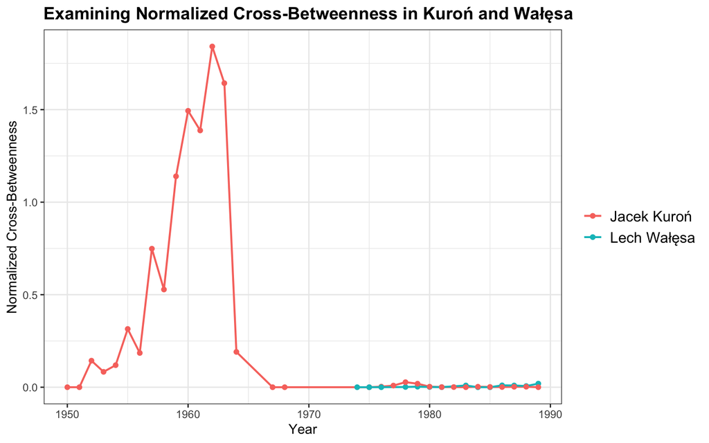

```r
# Comparing Walesa and Kuron as suggested by Bodwin

cncb_kuron_walesa <-
  joined |>
  filter(Full.Name %in% c("Jacek Kuroń", "Lech Wałęsa")) |>
    ggplot(mapping = aes(x = Start.Date,
                       y = Cross.Betweenness.Norm,
                       group = Member.ID,
                       color = Full.Name)) +
  geom_line(linewidth = .75) +
  geom_point() +
  labs(title = 'Examining Normalized Cross-Betweenness in Kuroń and Wałęsa',
       x = 'Year',
       y = 'Normalized Cross-Betweenness',
       color = '') +
  theme_bw() +
  theme(plot.title = element_text(face = "bold", size = 14),
        legend.text = element_text(size = 12))

cncb_kuron_walesa
```

```r
# I would like to see what individuals have the highest cross-betweenness on average
# filter the data down to include only these
# then visualize

top_5 <- joined |>
  group_by(Member.ID) |>
  summarise(avg_cb = mean(Cross.Betweenness.Norm),
            Full.Name = first(Full.Name),
            RT.Affiliation = first(RT.Affiliation)) |>
  arrange(desc(avg_cb)) |>
  slice_max(order_by = avg_cb, n = 5)

top_5 |>
  kable(format = "html", caption = "Highest 5 Average Norm Cross-Betweenness Over Time") |>
  kable_styling(bootstrap_options = c("striped", "hover", "condensed"), full_width = F)
```

Highest 5 Average Norm Cross-Betweenness Over Time

| Member.ID | avg_cb | Full.Name | RT.Affiliation |
| --- | --- | --- | --- |
| MEM0082 | 0.8245631 | Cezary Józefiak | Opposition |
| MEM0251 | 0.7592433 | Jan Rychlewski | Government |
| MEM0351 | 0.7502365 | Jerzy Kołodziejski | Government |
| MEM0229 | 0.7417449 | Andrzej Ziabicki | Expert |
| MEM0467 | 0.6760703 | Jacek Żochowski | Government |

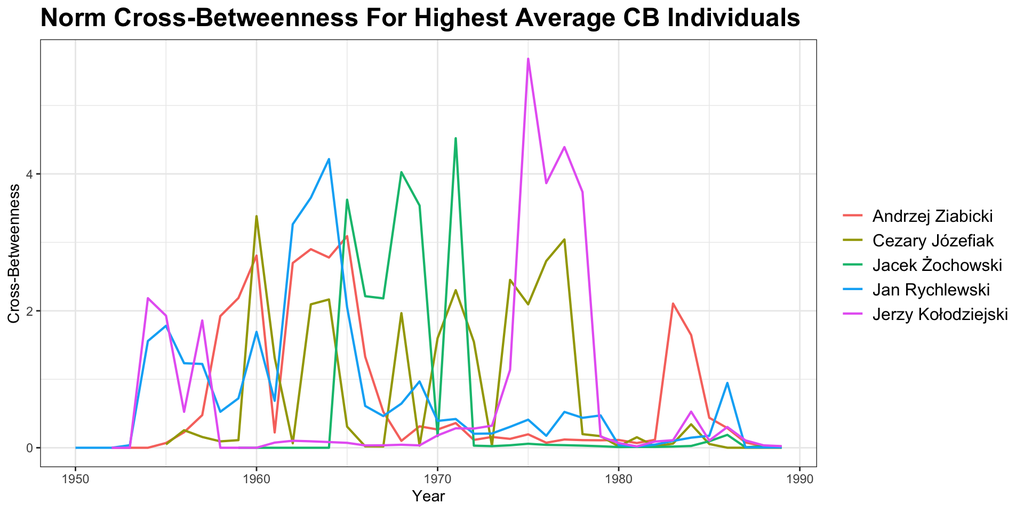

```r
cb_top_5_plot <- joined |>
  semi_join(top_5, by = 'Member.ID')

cb_top_5_plot |>
  ggplot(aes(x = Start.Date, y = Cross.Betweenness.Norm, color = Full.Name)) +
  geom_line(linewidth = 0.75) +
  # geom_point() +
  theme_bw() +
  labs(title = "Norm Cross-Betweenness For Highest Average CB Individuals",
       x = "Year",
       y = "Cross-Betweenness",
       color = "") +
   theme(plot.title = element_text(face = "bold", size = 18),
        legend.text = element_text(size = 12))
```

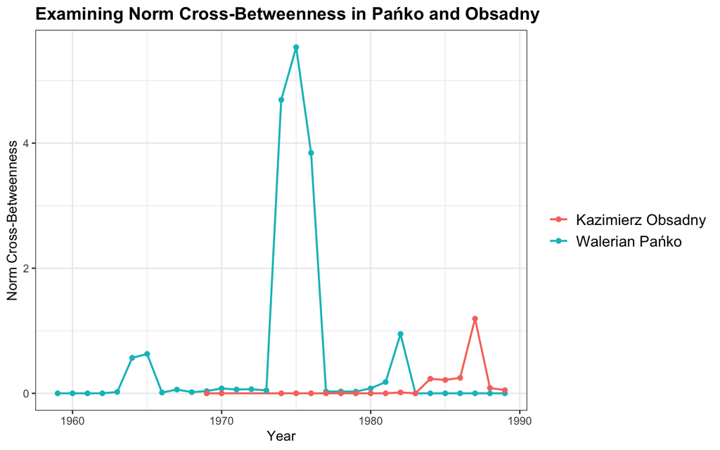

```r
# Comparing Pańko and Obsadny

cncb_panko_obsadny <-
  joined |>
  filter(Full.Name %in% c("Walerian Pańko", "Kazimierz Obsadny")) |>
    ggplot(mapping = aes(x = Start.Date,
                       y = Cross.Betweenness.Norm,
                       group = Member.ID,
                       color = Full.Name)) +
  geom_line(linewidth = .75) +
  geom_point() +
  labs(title = 'Examining Norm Cross-Betweenness in Pańko and Obsadny',
       x = 'Year',
       y = 'Norm Cross-Betweenness',
       color = '') +
  theme_bw() +
  theme(plot.title = element_text(face = "bold", size = 14),
        legend.text = element_text(size = 12))

cncb_panko_obsadny
```

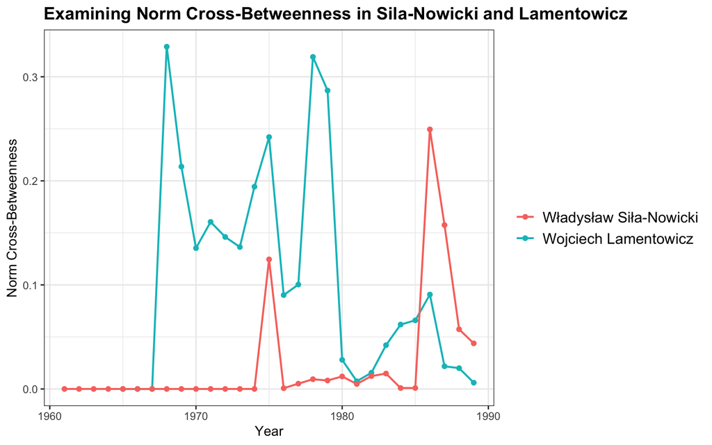

```r
# Comparing Wladyslaw Sila-Nowicki and Wojciech Lamentowicz

joined |>
  filter(Member.ID %in% c("MEM0252", "MEM0115")) |>
    ggplot(mapping = aes(x = Start.Date,
                       y = Cross.Betweenness.Norm,
                       group = Member.ID,
                       color = Full.Name)) +
  geom_line(linewidth = .75) +
  geom_point() +
  labs(title = 'Examining Norm Cross-Betweenness in Sila-Nowicki and Lamentowicz',
       x = 'Year',
       y = 'Norm Cross-Betweenness',
       color = '') +
  theme_bw() +
  theme(plot.title = element_text(face = "bold", size = 14),
        legend.text = element_text(size = 12))
```

### Comparing Spikes in CB and Cluster-Norm CB

In order to compare Cross-Betweenness and Cluster-Norm Cross-Betweenness, we need to look at instances of spikes in both scores and see if we can deduce what IAs are driving the spikes up. This will allow us to consult with Dr. Domber on which score is more useful / valid.

Let’s first take a look at Kuroń and Wałęsa.

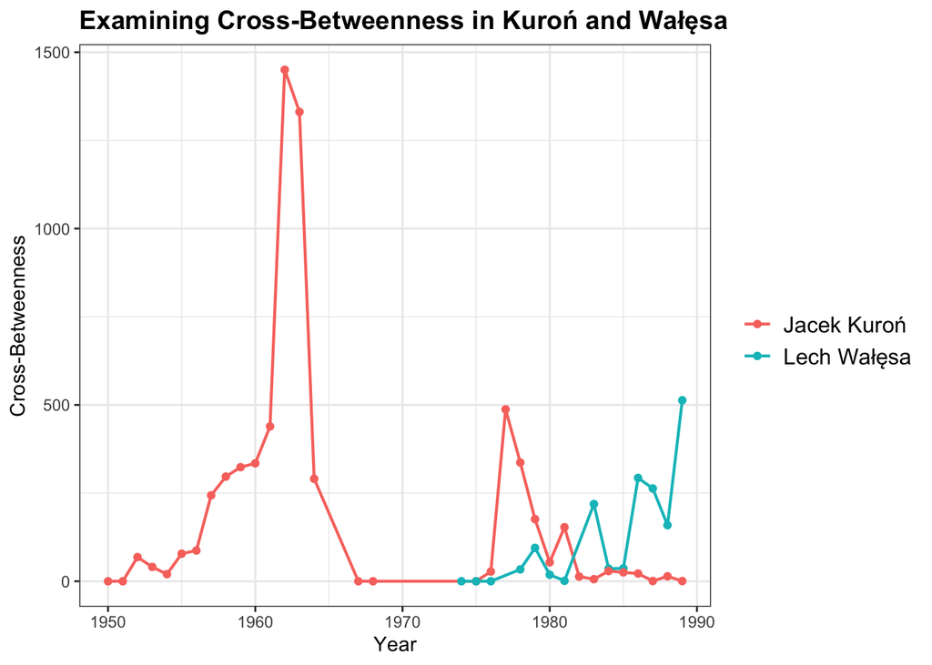

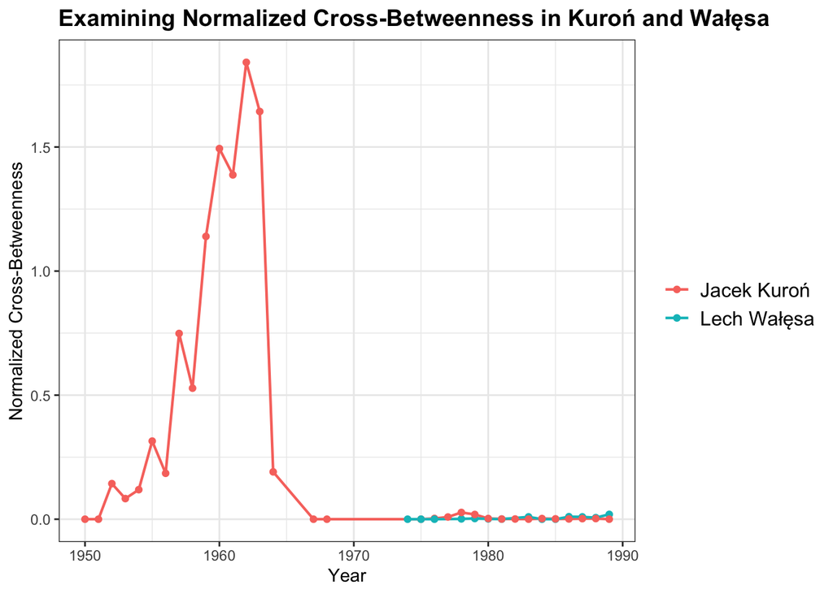

```r
# Plot 1
cb_kuron_walesa
# Plot 2
cncb_kuron_walesa
```

We can see that for both scores, Kuroń has a peak in 1962. This peak is not diminished with cluster-size normalization. Kuroń’s smaller bumps in 1952 and 1955-1960 are driven up with the normalization. Wałęsa’s spikes are almost completely flattened. Kuroń’s spike in 1978 is almost flattened, as well but we still see a small bump.

Let’s see what IAs are responsible for these spikes.

```r
# reading in affilation_dates
affil_dates <- read_csv('../clean_data/affiliation_dates.csv')

affil_dates <- affil_dates |>
  group_by(Org.ID) |>
  mutate(Org.Affiliation.Count = n()) |>
  ungroup()
```

```r
start_range <- as.Date("1955-01-01")
end_range <- as.Date("1965-12-31")

# filter affiliation dates to show Kuroń from 1955 to 1965
affil_dates |>
  filter(Full.Name == "Jacek Kuroń") |>
  filter(Start.Date <= end_range & End.Date >= start_range) |>
  select(Full.Name, Organization.Name, Org.ID, Start.Date, End.Date, Org.Affiliation.Count, Category) |>
  kable(format = "html",
        caption = "Jacek Kuroń Institutional Affiliations During Spike Activity 1955-65") |>
  kable_styling(bootstrap_options = c("striped", "hover", "condensed"), full_width = F) |>
  row_spec(row = c(1, 5, 6), background = "#DDFFDD")
```

Jacek Kuroń Institutional Affiliations During Spike Activity 1955-65

| Full.Name | Organization.Name | Org.ID | Start.Date | End.Date | Org.Affiliation.Count | Category |
| --- | --- | --- | --- | --- | --- | --- |
| Jacek Kuroń | Warsaw University Faculty of History | ORG02305 | 1952-09-01 | 1957-08-31 | 20 | Organization |
| Jacek Kuroń | PZPR Member | ORG01768 | 1952-01-01 | 1964-12-31 | 156 | Mass Organization |
| Jacek Kuroń | Polish Scouting Association | ORG02573 | 1955-01-01 | 1964-12-31 | 27 | Mass Organization |
| Jacek Kuroń | "Red Troop" Polish Scouting Association | ORG01878 | 1955-01-01 | 1964-12-31 | 1 | Organization |
| Jacek Kuroń | Union of Revolutionary Youth | ORG02284 | 1956-01-01 | 1957-12-31 | 2 | Organization |
| Jacek Kuroń | Association of Socialist Youth | ORG02586 | 1957-12-01 | 1962-11-30 | 32 | Mass Organization |
| Jacek Kuroń | Political Discussion Club | ORG01596 | 1962-01-01 | 1963-12-31 | 2 | Organization |

```r
start_range <- as.Date("1976-01-01")
end_range <- as.Date("1980-12-31")

# filter affiliation dates to show Kuroń from 1955 to 1965
affil_dates |>
  filter(Full.Name == "Jacek Kuroń") |>
  filter(Start.Date <= end_range & End.Date >= start_range) |>
  select(Full.Name, Organization.Name, Org.ID, Start.Date, End.Date, Org.Affiliation.Count, Category) |>
  kable(format = "html",
        caption = "Jacek Kuroń Institutional Affiliations During Spike Activity 1976-80") |>
  kable_styling(bootstrap_options = c("striped", "hover", "condensed"), full_width = F) |>
  row_spec(row = c(3, 4, 5, 8, 9, 10), background = "#FFDDDD")
```

Jacek Kuroń Institutional Affiliations During Spike Activity 1976-80

| Full.Name | Organization.Name | Org.ID | Start.Date | End.Date | Org.Affiliation.Count | Category |
| --- | --- | --- | --- | --- | --- | --- |
| Jacek Kuroń | Letter in Support of Workers at Radom and Ursus | ORG00930 | 1976-06-01 | 1976-06-30 | 9 | Event |
| Jacek Kuroń | Open Letter to Enrico Berlinguera | ORG01437 | 1976-07-01 | 1976-07-30 | 1 | Event |
| Jacek Kuroń | KOR Collaborator | ORG00777 | 1976-09-01 | 1977-09-30 | 21 | Organization |
| Jacek Kuroń | KSS-KOR Collaborator | ORG00797 | 1977-09-01 | 1981-09-29 | 24 | Organization |
| Jacek Kuroń | Society for Academic Courses | ORG02183 | 1978-01-01 | 1981-12-31 | 15 | Organization |
| Jacek Kuroń | Inter-factory Founding Committee Gdańsk | ORG01109 | 1980-09-01 | 1981-12-31 | 5 | Organization |
| Jacek Kuroń | NSZZ Solidarność Commission for National Understanding | ORG01317 | 1980-09-01 | 1981-12-31 | 15 | Organization |
| Jacek Kuroń | "Kultura" | ORG00822 | 1974-01-01 | 1989-02-01 | 3 | Organization |
| Jacek Kuroń | "ANEKS" | ORG00079 | 1977-01-01 | 1989-02-01 | 3 | Organization |
| Jacek Kuroń | "Biuletyn Informacyjny" KSS-KOR | ORG00139 | 1977-09-01 | 1981-09-30 | 12 | Organization |

Now looking at Wałęsa:

```r
start_range <- as.Date("1977-01-01")
end_range <- as.Date("1989-12-31")

# filter affiliation dates to show Walesa from 1977 to 1989
affil_dates |>
  filter(Full.Name == "Lech Wałęsa") |>
  filter(Start.Date <= end_range & End.Date >= start_range) |>
  select(Full.Name, Organization.Name, Org.ID, Start.Date, End.Date, Org.Affiliation.Count, Category) |>
  kable(format = "html",
        caption = "Lech Wałęsa Institutional Affiliations During Spike Activity 1977-1989") |>
  kable_styling(bootstrap_options = c("striped", "hover", "condensed"), full_width = F) |>
  row_spec(row = c(1, 2, 3, 4, 11, 14), background = "#FFDDDD")
```

Lech Wałęsa Institutional Affiliations During Spike Activity 1977-1989

| Full.Name | Organization.Name | Org.ID | Start.Date | End.Date | Org.Affiliation.Count | Category |
| --- | --- | --- | --- | --- | --- | --- |
| Lech Wałęsa | Coastal Free Trade Unions | ORG00202 | 1978-06-01 | 1980-08-31 | 4 | Organization |
| Lech Wałęsa | "Robotnik" | ORG01896 | 1978-07-01 | 1978-12-31 | 9 | Organization |
| Lech Wałęsa | "Robotnik Wybrzeża" | ORG01897 | 1979-01-01 | 1980-08-31 | 2 | Organization |
| Lech Wałęsa | KSS-KOR Collaborator | ORG00797 | 1979-01-01 | 1980-08-31 | 24 | Organization |
| Lech Wałęsa | Gdańsk Agreement signatory | ORG00513 | 1980-08-31 | 1980-08-31 | 4 | Event |
| Lech Wałęsa | Gdańsk Construction Mechanization Plant ZREMB | ORG00524 | 1976-07-01 | 1979-06-30 | 1 | Organization |
| Lech Wałęsa | Gdańsk "Elektromantaż" | ORG00529 | 1979-07-01 | 1980-05-03 | 1 | Organization |
| Lech Wałęsa | NSZZ Solidarność Commission for National Understanding | ORG01317 | 1980-09-01 | 1981-12-13 | 15 | Organization |
| Lech Wałęsa | First Solidarność National Congress Delegate | ORG00487 | 1981-10-01 | 1981-11-30 | 31 | Event |
| Lech Wałęsa | Interned Arłamow | ORG00699 | 1981-12-13 | 1982-11-14 | 1 | Event |
| Lech Wałęsa | NSZZ Solidarność Temporary Coordinating Commission | ORG01380 | 1983-04-01 | 1986-09-29 | 23 | Organization |
| Lech Wałęsa | NSZZ Solidarność Temporary Council | ORG01385 | 1986-09-29 | 1987-10-25 | 7 | Organization |
| Lech Wałęsa | NSZZ Solidarność National Executive Commission | ORG01319 | 1987-10-25 | 1989-02-01 | 32 | Organization |
| Lech Wałęsa | Lenin Shipyards Gdańsk | ORG00934 | 1983-01-01 | 1989-02-01 | 4 | Organization |
| Lech Wałęsa | Lenin Shipyards Gdańsk May 1988 Strikes | ORG00937 | 1988-05-01 | 1988-05-30 | 6 | Event |
| Lech Wałęsa | Lenin Shipyards Gdańsk August 1988 Strikes | ORG00938 | 1988-08-01 | 1988-08-31 | 3 | Event |
| Lech Wałęsa | Citizens Committee | ORG00219 | 1988-12-18 | 1989-02-01 | 92 | Organization |

Looking at Pańko and Obsadny could be helpful as well.

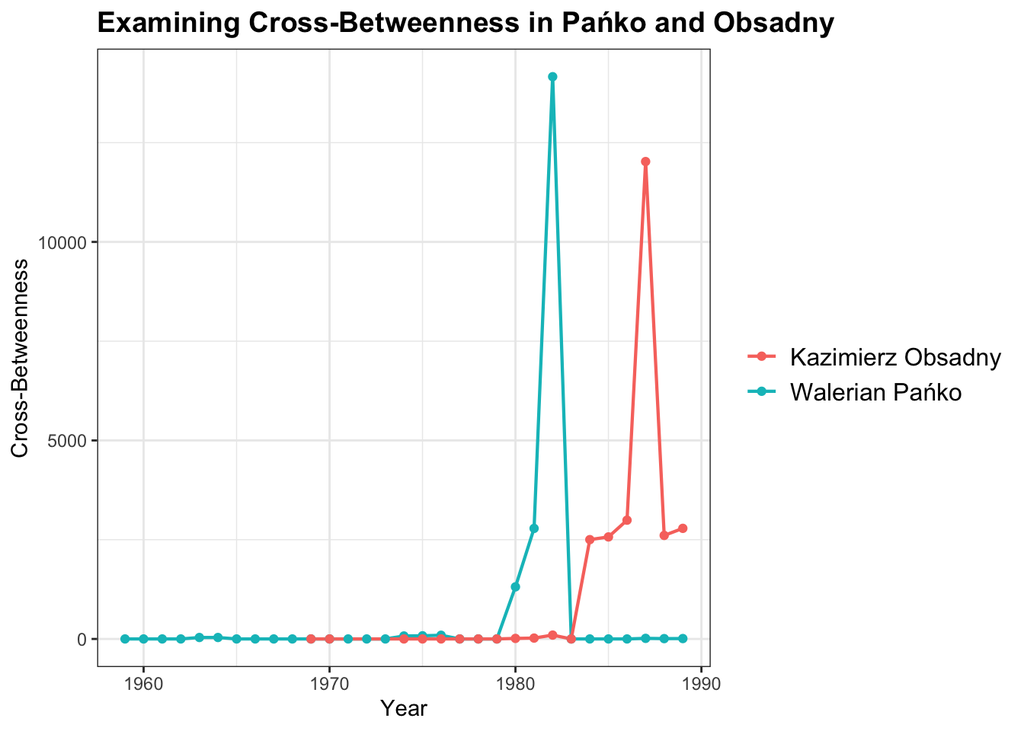

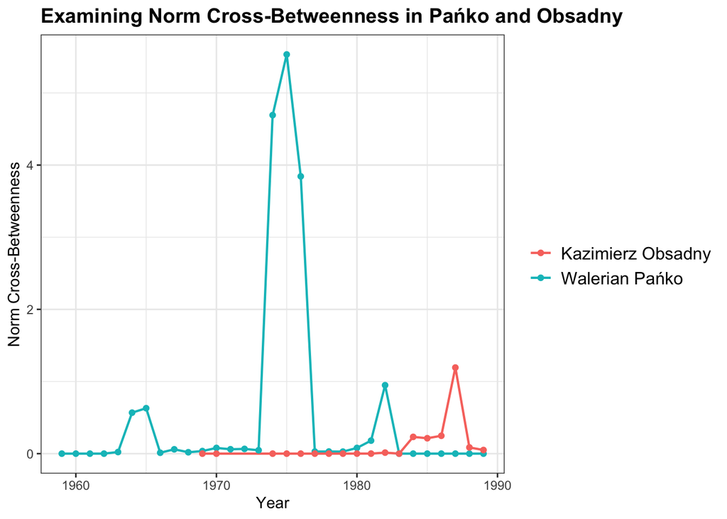

```r
# Plot 1
cb_panko_obsadny
# Plot 2
cncb_panko_obsadny
```

```r
start_range <- as.Date("1972-01-01")
end_range <- as.Date("1979-12-31")

# filter affiliation dates to show Walesa from 1973 to 1978
affil_dates |>
  filter(Full.Name == "Walerian Pańko") |>
  filter(Start.Date <= end_range & End.Date >= start_range) |>
  select(Full.Name, Organization.Name, Org.ID, Start.Date, End.Date, Org.Affiliation.Count, Category) |>
  kable(format = "html",
        caption = "Walerian Pańko Institutional Affiliations During Spike Activity 1972-1979") |>
  kable_styling(bootstrap_options = c("striped", "hover", "condensed"), full_width = F) |>
  row_spec(row = c(1, 2), background = "#DDFFDD")
```

Walerian Pańko Institutional Affiliations During Spike Activity 1972-1979

| Full.Name | Organization.Name | Org.ID | Start.Date | End.Date | Org.Affiliation.Count | Category |
| --- | --- | --- | --- | --- | --- | --- |
| Walerian Pańko | Wrocław University Department of Agricultural Law | ORG02507 | 1964-09-01 | 1974-08-31 | 1 | Organization |
| Walerian Pańko | Silesia University Faculty of Law and Administration | ORG02084 | 1974-09-01 | 1989-02-01 | 6 | Organization |
| Walerian Pańko | PZPR Member | ORG01768 | 1963-01-01 | 1982-02-01 | 156 | Mass Organization |

```r
start_range <- as.Date("1980-01-01")
end_range <- as.Date("1983-12-31")

# filter affiliation dates to show Walesa from 1980 to 1983
affil_dates |>
  filter(Full.Name == "Walerian Pańko") |>
  filter(Start.Date <= end_range & End.Date >= start_range) |>
  select(Full.Name, Organization.Name, Org.ID, Start.Date, End.Date, Org.Affiliation.Count, Category) |>
  kable(format = "html",
        caption = "Walerian Pańko Institutional Affiliations During Spike Activity 1980-1983") |>
  kable_styling(bootstrap_options = c("striped", "hover", "condensed"), full_width = F) |>
  row_spec(row = c(2, 3), background = "#FFDDDD")
```

Walerian Pańko Institutional Affiliations During Spike Activity 1980-1983

| Full.Name | Organization.Name | Org.ID | Start.Date | End.Date | Org.Affiliation.Count | Category |
| --- | --- | --- | --- | --- | --- | --- |
| Walerian Pańko | Silesia University Faculty of Law and Administration | ORG02084 | 1974-09-01 | 1989-02-01 | 6 | Organization |
| Walerian Pańko | PZPR Member | ORG01768 | 1963-01-01 | 1982-02-01 | 156 | Mass Organization |
| Walerian Pańko | NSZZ Solidarność Member | ORG01251 | 1980-10-01 | 1989-02-01 | 98 | Mass Organization |
| Walerian Pańko | NSZZ Individual Farmers "Solidarity" advisor | ORG01236 | 1981-01-01 | 1981-12-31 | 6 | Organization |
| Walerian Pańko | Rural Solidarność Rzeszow Agreement Signatory | ORG01922 | 1981-02-01 | 1981-02-28 | 4 | Event |
| Walerian Pańko | Social Legislative Council (Solidarność) | ORG02080 | 1981-01-01 | 1981-12-31 | 2 | Organization |
| Walerian Pańko | Academic Pastoral Care | ORG00087 | 1982-01-01 | 1989-02-01 | 4 | Organization |
| Walerian Pańko | Center for Civil Legislative Issues Solidarność | ORG00177 | 1981-01-17 | 1982-01-31 | 7 | Organization |

```r
start_range <- as.Date("1985-01-01")
end_range <- as.Date("1989-12-31")

# filter affiliation dates to show Obsadny from 1985 to 1989
affil_dates |>
  filter(Full.Name == "Kazimierz Obsadny") |>
  filter(Start.Date <= end_range & End.Date >= start_range) |>
  select(Full.Name, Organization.Name, Org.ID, Start.Date, End.Date, Org.Affiliation.Count, Category) |>
  kable(format = "html",
        caption = "Kazimierz Obsadny Institutional Affiliations During Spike Activity 1985-1989") |>
  kable_styling(bootstrap_options = c("striped", "hover", "condensed"), full_width = F) |>
  row_spec(row = c(2, 3, 4, 6), background = "#FFDDDD")
```

Kazimierz Obsadny Institutional Affiliations During Spike Activity 1985-1989

| Full.Name | Organization.Name | Org.ID | Start.Date | End.Date | Org.Affiliation.Count | Category |
| --- | --- | --- | --- | --- | --- | --- |
| Kazimierz Obsadny | Mechanical Equipment Factory Ponar Ostrzeszów | ORG00497 | 1965-01-01 | 1989-02-06 | 1 | Organization |
| Kazimierz Obsadny | Democratic Party Member | ORG01978 | 1984-01-01 | 1989-02-06 | 16 | Mass Organization |
| Kazimierz Obsadny | NSZZ Solidarność Member | ORG01251 | 1980-09-01 | 1989-02-06 | 98 | Mass Organization |
| Kazimierz Obsadny | Pastoral Care for Working People | ORG01593 | 1985-01-01 | 1989-02-06 | 14 | Organization |
| Kazimierz Obsadny | Mass for the Fatherland | ORG01013 | 1984-01-01 | 1986-12-31 | 4 | Organization |
| Kazimierz Obsadny | All-Poland Alliance of Trade Unions Member | ORG01450 | 1987-03-01 | 1987-10-30 | 44 | Mass Organization |
| Kazimierz Obsadny | Radio Solidarność in Ostrzeszow | ORG01912 | 1987-01-01 | 1989-02-06 | 1 | Organization |
| Kazimierz Obsadny | NSZZ Solidarność Workers at the Pomar Mechanical Equipment Plant | ORG02701 | 1987-03-01 | 1989-02-06 | 1 | Organization |

## Orgs-as-Nodes Metric Exploration

### PageRank in Undirected Orgs-as-Nodes

**What is PageRank?**  
Variant of eigen centrality that accounts for directed edges and includes damping factor to consider probability of flow between nodes.

**What it describes in the network?**  
Organizations with high PageRank scores are “important” because they are connected to many other important organizations.

For example, a university that shares many members with PZPR or Solidarity will have a high PageRank.

```r
edgelist_orgs <- read_csv("/Users/chelseyharper/Capstone/PolandRoundTable/capstone/edgelist-orgs.csv")
```

```r
orgs_edges <- edgelist_orgs |>
  filter(from != to) |>
  arrange(desc(num_members))

# orgs_edges

g <- graph_from_data_frame(orgs_edges, directed = FALSE)

E(g)$weight <- orgs_edges$num_members
```

```r
page_rank_undirected <- page_rank(g, directed = FALSE,
                                  weights = E(g)$weight)

nodes_with_pagerank <- data.frame(
  Org.ID = V(g)$name,
  PageRank = page_rank_undirected$vector
)

# nodes_with_pagerank |>
#   arrange(desc(PageRank))
```

```r
org_meta <- read_csv('../clean_data/organization_meta_info.csv')
```

Using bidirectional graph, we can interpret the pageRank as the probability of ‘passing’ through a node on a random walk through the graph.

```r
org_pr <- nodes_with_pagerank |>
  inner_join(org_meta, by = 'Org.ID')
```

```r
org_pr |>
  arrange(desc(PageRank)) |>
  slice_max(order_by = PageRank, n=10) |>
  kable(format = "html",
        caption = "PageRank Scores for Organizations") |>
  kable_styling(bootstrap_options = c("striped", "hover", "condensed"), full_width = F)
```

PageRank Scores for Organizations

| Org.ID | PageRank | Organization.Name | Umbrella | Subgroup | Type | Category | Alternate.Names | Umbrella.Name |
| --- | --- | --- | --- | --- | --- | --- | --- | --- |
| ORG01768 | 0.0235432 | PZPR Member | PZPR | NA | Political Party | Mass Organization | Polska Zjednoczona Partia Robotnicza ; PZPR member | PZPR Member |
| ORG01251 | 0.0144317 | NSZZ Solidarność Member | NSZZS | NA | Opposition Group | Mass Organization | Solidarity | NSZZ Solidarność Member |
| ORG00219 | 0.0133799 | Citizens Committee | CITCOM | NA | Opposition Group Leadership Body National | Organization | Citizen's Committee ; Citizens committee | Citizens Committee |
| ORG02585 | 0.0091464 | Association of Polish Youth | ZMP | NA | PRL NGO | Mass Organization | Związek Młodzieży Polskiej ; Union of Polish Youth | Association of Polish Youth |
| ORG02308 | 0.0074988 | Warsaw University Faculty of Law and Administration | UW | FLAA | Postsecondary School | Organization | Wydział Prawa i Administracja Uniwersytetu Warszawskiego ; Warsaw Universitz Faculty of Law and Administration | Warsaw University |
| ORG00698 | 0.0066635 | Interned | INT | NA | Protest Action | Event | interned | Interned |
| ORG02663 | 0.0060920 | Union of Polish Students | ZSP | NA | PRL NGO | Mass Organization | Zrzeszenie Studentów Polskich ; "Orzecznictwo Sądów Polskich" | Union of Polish Students |
| ORG01319 | 0.0054469 | NSZZ Solidarność National Executive Commission | NSZZS | KKW | Opposition Group Leadership Body National | Organization | NA | NSZZ Solidarność Member |
| ORG02586 | 0.0046659 | Association of Socialist Youth | ZMS | NA | PRL NGO | Mass Organization | Związek Młodzieży Socjalistycznej | Association of Socialist Youth |
| ORG00797 | 0.0046187 | KSS-KOR Collaborator | KSSKOR | NA | Opposition Group | Organization | NA | KSS-KOR Collaborator |

### Orgs-as-Nodes Government and Opposition Comparison

```r
# Creating orgs nodes graph with only government affiliations

gov_g <- graph_from_data_frame(orgs_edges, directed = FALSE)
E(gov_g)$weight <- orgs_edges$Government

# Creating orgs nodes graph with only Opposition affiliations

opp_g <- graph_from_data_frame(orgs_edges, directed = FALSE)
E(opp_g)$weight <- orgs_edges$Opposition
```

```r
calculate_metrics <- function(g, inv_weight = FALSE) {
  if (inv_weight) {
    E(g)$weight <- 1 / E(g)$weight
  }

  metrics <- data.frame(
    Org.ID = V(g)$name,
    Degree = degree(g),
    Strength = strength(g),
    Betweenness = betweenness(g, weights = if (inv_weight) E(g)$weight else NA),
    Closeness = closeness(g, weights = if (inv_weight) E(g)$weight else NA),
    # Eigenvector = eigen_centrality(g)$vector,
    PageRank = page_rank(g, directed = FALSE, weights = E(g)$weight)$vector
  )

  return(metrics)
}
```

```r
#Calculate metrics for government graph
gov_metrics <- calculate_metrics(gov_g, inv_weight = TRUE)

# Calculate metrics for opposition graph
opp_metrics <- calculate_metrics(opp_g, inv_weight = TRUE)
```

```r
# gov_metrics <- gov_metrics |>
#   mutate(Graph = "Government")
#
# opp_metrics <- opp_metrics |>
#   mutate(Graph = "Opposition")
#
# combined_metrics <- bind_rows(gov_metrics, opp_metrics)

# print(combined_metrics, row.names = FALSE)
```

## CB Results with Aggregation

```r
# loading results of candidate variant #1 "Cross Betweenness"
cb_by_month <- read_csv("cb_monthly_results.csv")

cb_by_month |> arrange(desc(CrossBetweenness)) |>
  slice_max(order_by = CrossBetweenness, n = 20) |>
  kable(format = "html", caption = "Highest 20 Monthly Cross-Betweenness Results") |>
  kable_styling(bootstrap_options = c("striped", "hover", "condensed"), full_width = F)
```

Highest 20 Monthly Cross-Betweenness Results

| Member.ID | CrossBetweenness | Start.Date | End.Date | Full.Name | RT.Affiliation |
| --- | --- | --- | --- | --- | --- |
| MEM0142 | 28360.079 | 1982-02-01 | 1982-02-28 | Walerian Pańko | Opposition |
| MEM0142 | 27642.361 | 1982-01-01 | 1982-01-31 | Walerian Pańko | Opposition |
| MEM0272 | 24593.315 | 1987-10-01 | 1987-10-31 | Kazimierz Obsadny | Government |
| MEM0272 | 24427.561 | 1987-09-01 | 1987-09-30 | Kazimierz Obsadny | Government |
| MEM0272 | 24308.062 | 1987-08-01 | 1987-08-31 | Kazimierz Obsadny | Government |
| MEM0272 | 24303.973 | 1987-07-01 | 1987-07-31 | Kazimierz Obsadny | Government |
| MEM0272 | 24252.451 | 1987-03-01 | 1987-03-31 | Kazimierz Obsadny | Government |
| MEM0272 | 24251.149 | 1987-04-01 | 1987-04-30 | Kazimierz Obsadny | Government |
| MEM0272 | 24171.308 | 1987-06-01 | 1987-06-30 | Kazimierz Obsadny | Government |
| MEM0272 | 23925.444 | 1987-05-01 | 1987-05-31 | Kazimierz Obsadny | Government |
| MEM0229 | 10840.027 | 1985-05-01 | 1985-05-31 | Andrzej Ziabicki | Expert |
| MEM0229 | 9869.375 | 1985-08-01 | 1985-08-31 | Andrzej Ziabicki | Expert |
| MEM0229 | 9868.825 | 1985-07-01 | 1985-07-31 | Andrzej Ziabicki | Expert |
| MEM0229 | 9838.021 | 1985-06-01 | 1985-06-30 | Andrzej Ziabicki | Expert |
| MEM0247 | 9364.731 | 1989-01-01 | 1989-01-01 | Alfred Miodowicz | Government |
| MEM0229 | 9238.228 | 1985-10-01 | 1985-10-31 | Andrzej Ziabicki | Expert |
| MEM0229 | 9175.877 | 1985-12-01 | 1985-12-31 | Andrzej Ziabicki | Expert |
| MEM0229 | 9123.620 | 1985-11-01 | 1985-11-30 | Andrzej Ziabicki | Expert |
| MEM0229 | 9112.155 | 1983-09-01 | 1983-09-30 | Andrzej Ziabicki | Expert |
| MEM0229 | 9112.155 | 1983-10-01 | 1983-10-31 | Andrzej Ziabicki | Expert |

```r
cb_by_month <- cb_by_month |>
  mutate(Year = format(as.Date(Start.Date), "%Y"))

yearly_avg <- cb_by_month |>
  group_by(Member.ID, Full.Name, RT.Affiliation, Year) |>
  summarise(
    Yearly_Avg_CrossBetweenness = mean(CrossBetweenness, na.rm = TRUE)
  ) |>
  ungroup()

overall_avg <- yearly_avg  |>
  group_by(Member.ID, Full.Name, RT.Affiliation)  |>
  summarise(
    Overall_Avg_CrossBetweenness = mean(Yearly_Avg_CrossBetweenness, na.rm = TRUE)
  ) |>
  ungroup()

top_20_individuals <- overall_avg  |>
  arrange(desc(Overall_Avg_CrossBetweenness)) |>
  slice_max(order_by = Overall_Avg_CrossBetweenness, n = 20) |>
  kable(format = "html", caption = "Highest 20 Aggregate Cross-Betweenness Results") |>
  kable_styling(bootstrap_options = c("striped", "hover", "condensed"), full_width = F)

top_20_individuals
```

Highest 20 Aggregate Cross-Betweenness Results

| Member.ID | Full.Name | RT.Affiliation | Overall_Avg_CrossBetweenness |
| --- | --- | --- | --- |
| MEM0272 | Kazimierz Obsadny | Government | 2662.7280 |
| MEM0084 | Stefan Jurczak | Opposition | 2362.8932 |
| MEM0229 | Andrzej Ziabicki | Expert | 2197.3613 |
| MEM0462 | Jan Waleczek | Government | 2107.6384 |
| MEM0139 | Edward Olszewski | Expert | 1963.3718 |
| MEM0065 | Andrzej Grudziński | Opposition | 1628.0306 |
| MEM0115 | Wojciech Lamentowicz | Opposition | 1591.7541 |
| MEM0165 | Henryk Rutkowski | Opposition | 1526.4541 |
| MEM0351 | Jerzy Kołodziejski | Government | 1502.8510 |
| MEM0247 | Alfred Miodowicz | Government | 1368.0380 |
| MEM0066 | Janusz Grzelak | Opposition | 1307.5599 |
| MEM0230 | Tadeusz Zieliński | Opposition | 1141.3912 |
| MEM0478 | Jan Jachymek | Government | 1139.1065 |
| MEM0485 | Jerzy Wiatr | Government | 1077.4637 |
| MEM0314 | Ireniusz Sekuła | Government | 1053.8074 |
| MEM0223 | Henryk Wujec | Opposition | 1037.8063 |
| MEM0039 | Andrzej Dobrucki | Opposition | 1033.2629 |
| MEM0417 | Adam Andrzejewski | Government | 1013.0461 |
| MEM0297 | Władysław Baka | Government | 1010.7178 |
| MEM0307 | Jerzy Ozdowski | Government | 984.6823 |

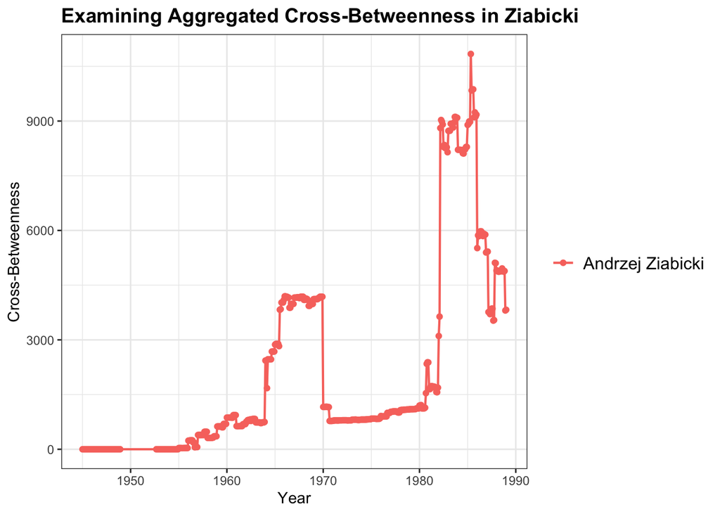

```r
cb_agg_ziabicki <-
  cb_by_month |>
  filter(Full.Name %in% c("Andrzej Ziabicki")) |>
    ggplot(mapping = aes(x = Start.Date,
                       y = CrossBetweenness,
                       group = Member.ID,
                       color = Full.Name)) +
  geom_line(linewidth = .75) +
  geom_point() +
  labs(title = 'Examining Aggregated Cross-Betweenness in Ziabicki',
       x = 'Year',
       y = 'Cross-Betweenness',
       color = '') +
  theme_bw() +
  theme(plot.title = element_text(face = "bold", size = 14),
        legend.text = element_text(size = 12))

cb_agg_ziabicki
```

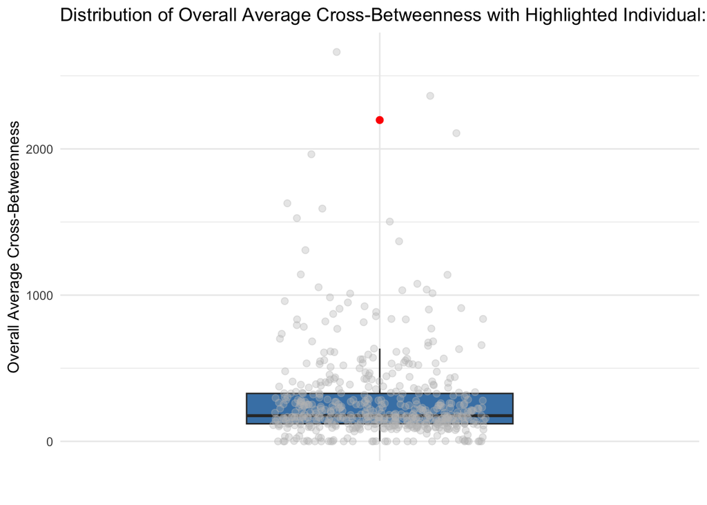

```r
individual_to_highlight <- "Andrzej Ziabicki"

overall_avg <- overall_avg |>
  mutate(Highlight = ifelse(Full.Name == individual_to_highlight, "Highlighted", "Not Highlighted"))


ggplot(overall_avg, aes(x = "", y = Overall_Avg_CrossBetweenness)) +
  geom_boxplot(width = 0.5, fill = "steelblue", outlier.shape = NA) +
  geom_jitter(aes(color = Highlight, alpha = Highlight), width = 0.2, size = 2) +
  scale_color_manual(values = c("Highlighted" = "red", "Not Highlighted" = "gray")) +
  scale_alpha_manual(values = c("Highlighted" = 1, "Not Highlighted" = 0.35), guide = "none") +
  labs(title = paste("Distribution of Overall Average Cross-Betweenness with Highlighted Individual:", individual_to_highlight),
       x = "",
       y = "Overall Average Cross-Betweenness") +
  theme_minimal() +
  theme(legend.position = "none")
```

## What We Accomplished This Week

- Jack pushed Orgs-as-Nodes to Dr. Bodwin’s Repo
  - Dr. Bodwin will have it integrated by the end of the week
- Function Optimization for CB and CNCB

## We’re Still Working On

- We have created a more optimized version of CB and CNCB so that we may get more granular scores and aggregate properly
  - But we are running into snags – this needs more work
- We are integrating CB and CNCB functionality into the Shiny app
  - customization questions
  - boxplot for understanding individual placement in broader landscape?
  - populate IAs for given time range?

## What We Are Still Planning

- Investigating EdgeBetweenness in both networks
- Nailing down interpretations for orgs graph metrics

## Saving for Later

- Another metric (formulated with Dr. Domber’s ratio idea + eigencentrality)